# E-Scooters

## Cleaning and validation

### Season

| date | hour | season |
| --- | --- | --- |
| 2011-01-01 | 0 | 1 |

- The information pack lists season code 1 as spring so January would be in spring.
- This is not the case in either hemisphere so the codes are incorrectly ordered.
- I calculated the average temperature by season to determine the correct order of the season codes.

| season code | mean temperature |
| --- | --- |
| 1 | 12.26501 |
| 2 | 22.33119 |
| 3 | 28.96282 |
| 4 | 17.34866 |

- Summer, being the hottest season, should be coded as 3 while winter should be 1.
- Subsequently, spring is 2 and autumn is 4.

## Cleaning and validation

### Holiday or Working Day

| date | hour | season | holiday | workingday |
| --- | --- | --- | --- | --- |
| 2011-01-01 | 0 | Winter | 0 | 0 |

- January 1st is not listed as a holiday but in many countries, it is a public holiday.
- Using `wday()` from `lubridate`, I checked which day of the week January 1st landed on in 2011 and 2012. It was a Saturday and a Sunday, respectively.
- As such, I expected 3rd January 2011 and 2nd January 2012 to be listed as holidays. However, only the latter was.
- As I do not know which country the data is from, I have left these columns as they are.

## Cleaning and validation

### Aggregating by date and verifying the distribution

- Shapiro-Wilk test indicated the daily rental data are not normally distributed (w = 0.980, p = 2.08x10<sup>-8</sup>).
- Histogram and quantile plots of the data show that the distribution is approximately normal.
- The subsequent analysis will assume the data is normally distributed.

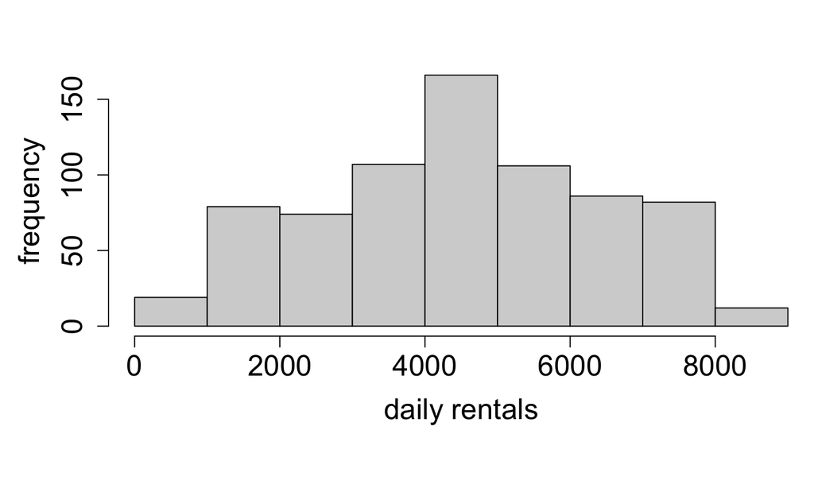

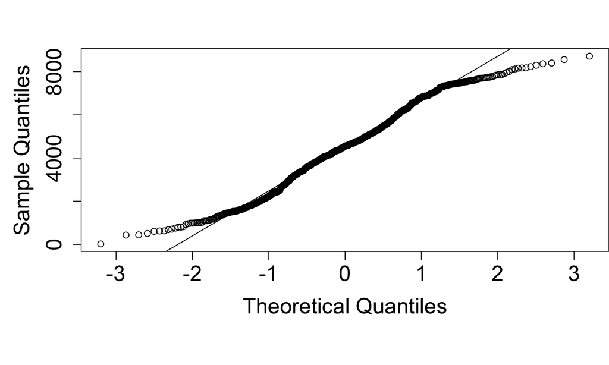

## Daily Rental Statistics

### Methods

- As the data are normally distributed, the mean is used to calculate the average number of daily rentals
- The summary statistics per season calculated are:
  - sample size
  - total sum of e-scooters rented
  - mean
  - standard deviation
  - minimum and maximum
- Significance testing of the means is first carried out using a pairwise t-test across seasons and then two sample t-tests.
- Significance testing of the variance is carried out with Levene’s test and F-tests.
- Pearson’s correlation coefficient is used to measure correlations.

## Daily Rental Statistics

### Summary

- Summer saw the greatest number of rentals followed by spring, autumn and, finally, winter.
- Summer averaged 2.2x more daily rentals than winter. This is a statistically significant difference (two sample t-test: t = -20.421, df = 366.99, p-value = 2.2e-16).
- Spring had a slightly higher average number of daily rentals than autumn. This is not statistically significant (two sample t-test: t = -1.48, df = 359.55, p-value = 0.1398).
- The standard deviation of the average number of daily rentals is highest for autumn followed by spring, summer and winter.

| season | sample size | sum | mean | sd | min | max |
| --- | --- | --- | --- | --- | --- | --- |
| Autumn | 178 | 841613 | 4728 | 1700 | 22 | 8555 |
| Spring | 184 | 918589 | 4992 | 1696 | 795 | 8362 |
| Summer | 188 | 1061129 | 5644 | 1460 | 1115 | 8714 |
| Winter | 181 | 471348 | 2604 | 1400 | 431 | 7836 |

## Daily Rental Statistics

### Summary

- Summer and winter have similar standard deviations, as do spring and autumn.
- There is a significant difference between spring’s sd and summer and winter’s. Similarly, autumn’s sd is significantly different to summer and winter’s.

|  | Spring | Summer | Autumn | Winter |
| --- | --- | --- | --- | --- |
| Spring | - |  |  |  |
| Summer | **0.041** | - |  |  |
| Autumn | 0.976 | **0.040** | - |  |
| Winter | **0.010** | 0.572 | **0.010** | - |

Pairwise F-test p-values. Statistically significant values in bold.

## Daily Rental Statistics

### Summary

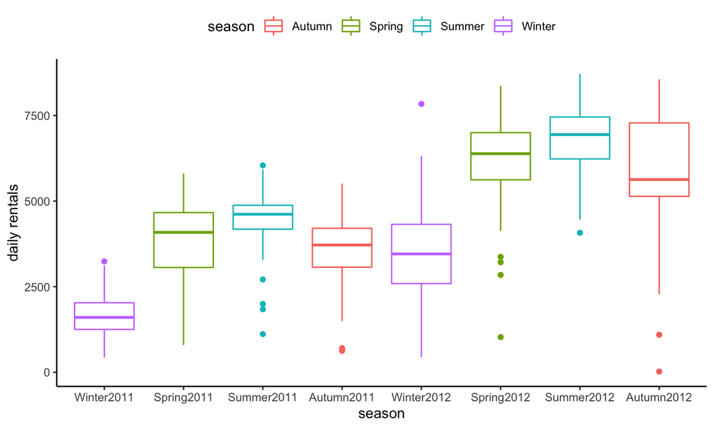

## Daily Rental Statistics

### What might be driving seasonal variation?

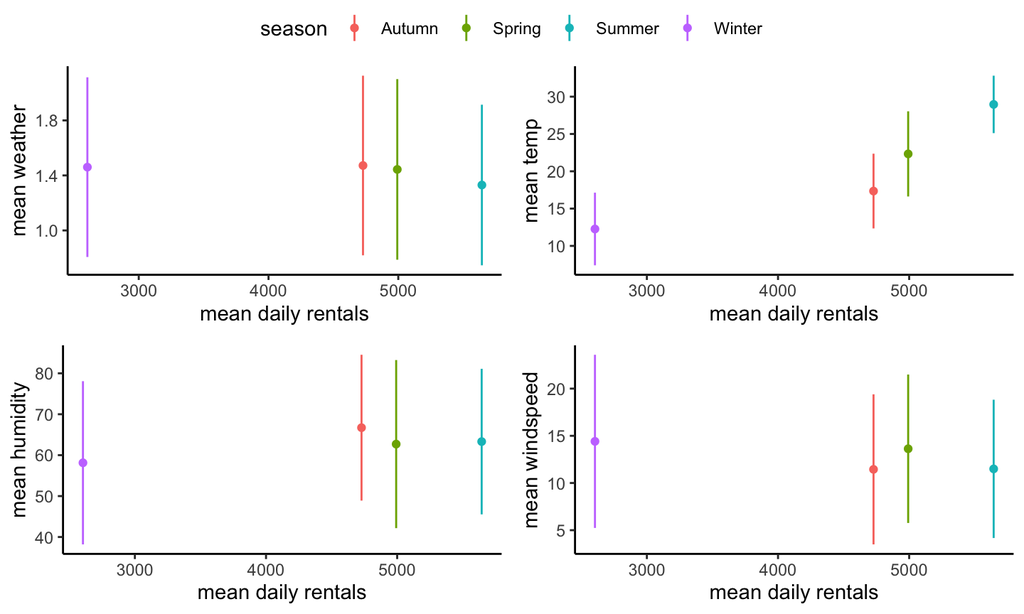

## Daily Rental Statistics

### Temperature

- There appears to be a positive relationship between temperature and mean daily rentals. Testing for correlation, we obtain a Pearson’s r of 0.90 (t = 3.006, df = 2, p-value = 0.09514). It is not statistically significant but there is a strong correlation.
- Similarly, there is a strong correlation between “feels like” temperature and mean daily rentals (r = 0.92, t = 3.2399, df = 2, p-value = 0.0835) that is statistically non-significant.

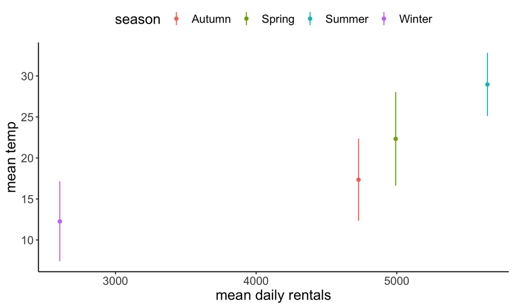

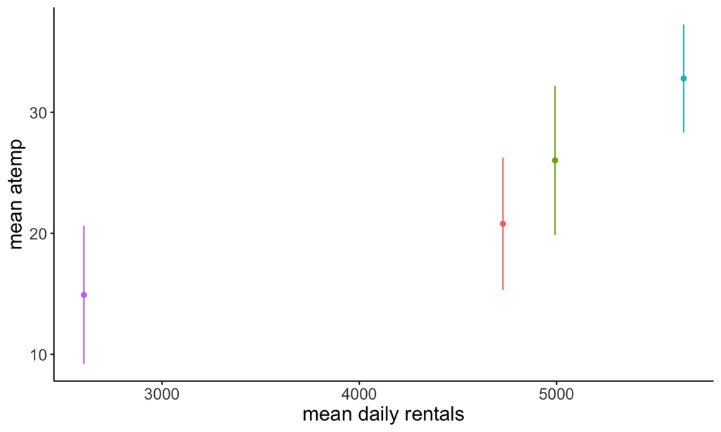

## Predicting Daily Rentals

### Time Series Analysis

1. Plot the time series to visualise the overall trends in the data.
2. Decompose the series to estimate trends and seasonal effects using a moving average method.
3. Calculate autocorrelation and partial autocorrelation to define the relationship between a variable and itself at previous time points.
4. Apply an ARIMA model that can then be used to predict daily rentals.

## Predicting Daily Rentals

### Time Series Analysis

1. Plot the time series to visualise the overall trends in the data.

Daily rentals increases from the start of the year, peaks in the summer and falls with there being an increase in daily rentals between 2011 and 2012.

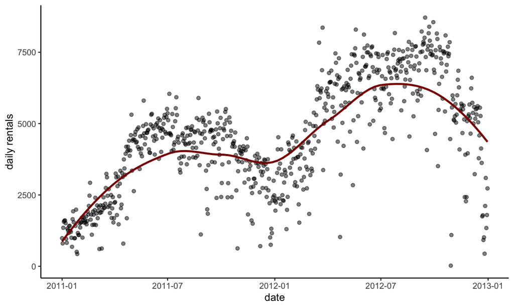

## Predicting Daily Rentals

### Time Series Analysis

1. Decompose the series to estimate trends and seasonal effects using a moving average method.

There is trend for daily rentals to grow and we see some troughs either side of summer 2011 and summer 2012.

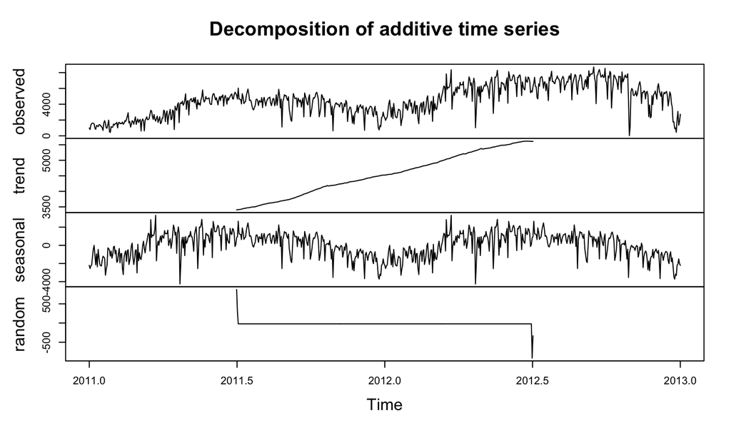

## Predicting Daily Rentals

### Time Series Analysis

1. Calculate autocorrelation and partial autocorrelation to define the relationship between a variable and itself at previous time points.

The autocorrelation plot indicates that for the next 30 time points, the value at time point x will have a strong influence. But, the partial autocorrelation tells us that beyond 7 time points from x, there is a lot of noise associated with correlations from the intervening time points.

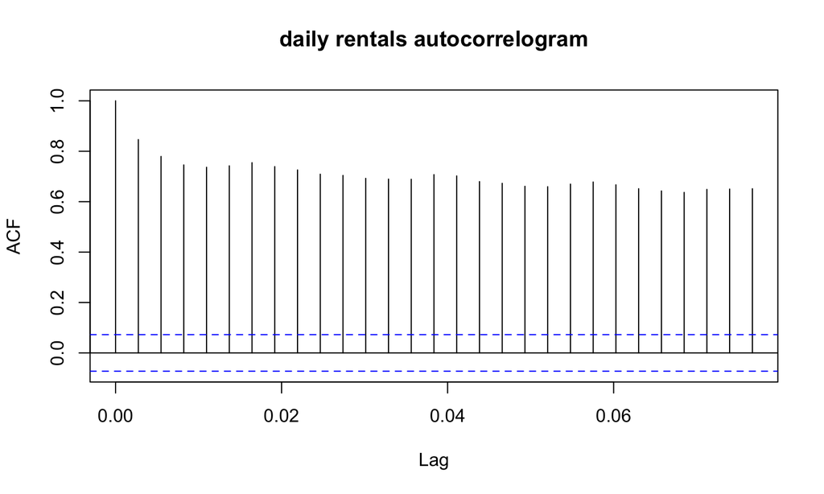

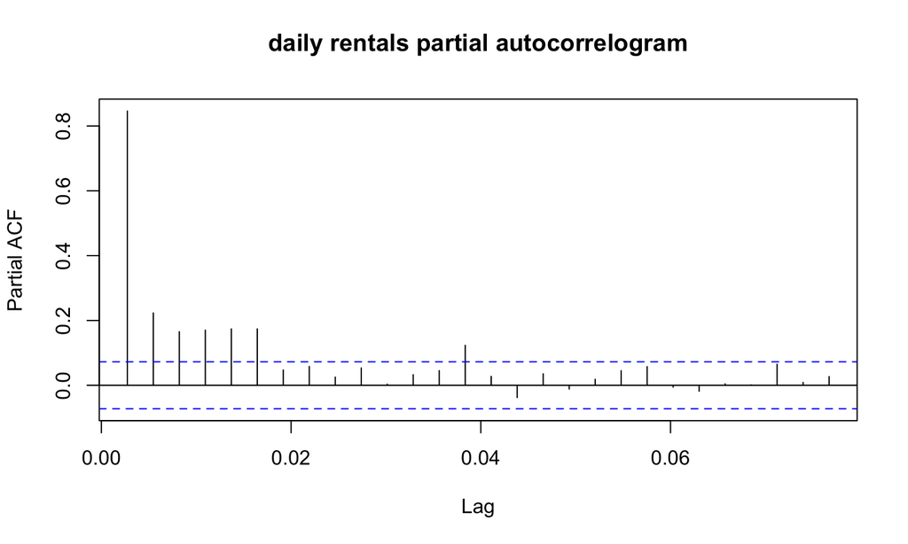

## Predicting Daily Rentals

### Time Series Analysis

1. Apply an ARIMA model that can then be used to predict daily rentals.

AR - autoregressive: using previous values to predict future values.  
I - integrated: applying a transformation to make the mean of the time series stationary.  
MA - moving-average model: incorporating error terms for forecasting.

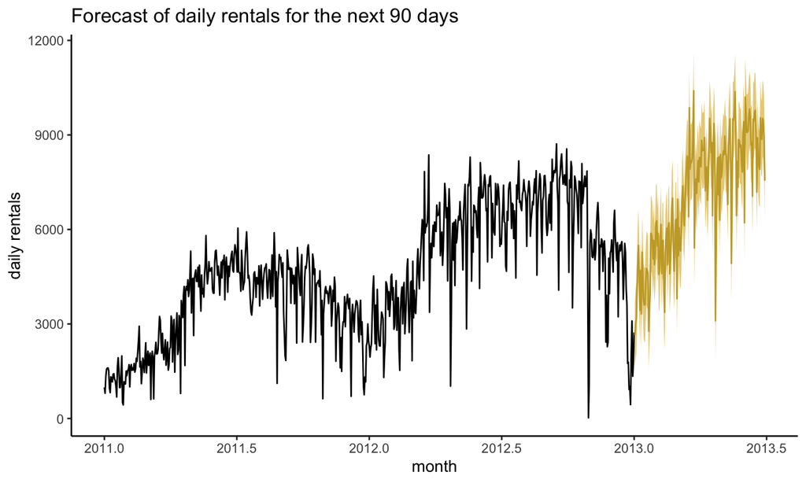

Code used for the analysis and creating this presentation can be found on GitHub: https://github.com/akhileshsivaraman/E-Scooters